# CFBD API Vignette

Maxwell Su

For this vignette I will use the following packages:

- `httr`
- `jsonlite`
- `tidyverse`
- `maps`

Where `httr` and `jsonlite` are used for accessing the API, and `tidyverse` is used for processing and presenting the data pulled. `maps` is used to aid in plotting coordinates.

The first function to write simply takes in the user’s API key and processes it in a way that the API can use.

```r
getAPIKey <- function(apiKey){
  output <- paste("Bearer", apiKey)
  return(output)
}
```

`teams`

The first real function provides details on each team that the database has information on. The optional argument `conference` when specified returns only teams in that conference. Conferences must be provided in abbreviated form (such as `ACC`, `PAC`, or `SEC`).

The last parameter is the API key, required to access the data.

This function, as well as the remaining functions, pulls data from the database by starting with a base URL to query and adding additional parameters to the URL. The resulting data is then processed into a presentable data format.

```r
teams <- function(conference = "", apiKey){
  string <- "https://api.collegefootballdata.com/teams"
  if(conference != ""){
    string <- paste(string, "?conference=", conference, sep = "")
  }
  output <- GET(string, add_headers(Authorization = apiKey, Accept = "application/json"))
  output <- rawToChar(output$content)
  output <- fromJSON(output, flatten = TRUE)
  return(output)
}
```

`games`

The next function queries the games in the database. The size of this data means that a `year` must be specified, and even then an additional condition is suggested in order to reduce the overhead. Of the remaining filters, the ones I have chosen are `week` and `team`.

The games are split into regular season and postseason games, with the season type needing to be specified. By default, the output will be of regular season games.

```r
games <- function(year, week = "", seasonType = "regular", team = "", apiKey){
  string <- paste("https://api.collegefootballdata.com/games?year=", year, sep = "")
  if(week != ""){
    string <- paste(string, "&week=", week, sep = "")
  }
  string <- paste(string, "&seasonType=", seasonType, sep = "")
  if(team != ""){
    team <- gsub(" ", "%20", team)
    string <- paste(string, "&team=", team, sep = "")
  }
  output <- GET(string, add_headers(Authorization = apiKey, Accept = "application/json"))
  output <- rawToChar(output$content)
  output <- fromJSON(output, flatten = TRUE)
  return(output)
}
```

`records`

This function returns win-loss data for teams. The API requires that at least one of `year` and `team` is specified. The optional parameter `conference` can be used to output conference standings for a year.

```r
records <- function(year = "", team = "", conference = "", apiKey){
  string <- paste("https://api.collegefootballdata.com/records?")
  if(year != ""){
    string <- paste(string, "year=", year, "&", sep = "")
  }
  if(team != ""){
    team <- gsub(" ", "%20", team)
    string <- paste(string, "team=", team, "&", sep = "")
  }
  if(conference != ""){
    string <- paste(string, "conference=", conference, "&",sep = "")
  }
  string <- str_sub(string, end = -2)
  output <- GET(string, add_headers(Authorization = apiKey, Accept = "application/json"))
  output <- rawToChar(output$content)
  output <- fromJSON(output, flatten = TRUE)
  return(output)
}
```

`venues`

This function returns data on the stadiums where college football games have been played. There are no optional arguments.

```r
venues <-  function(apiKey){
  string <- paste("https://api.collegefootballdata.com/venues")
  output <- GET(string, add_headers(Authorization = apiKey, Accept = "application/json"))
  output <- rawToChar(output$content)
  output <- fromJSON(output, flatten = TRUE)
  return(output)
}
```

`roster`

This function returns roster data for teams. Optional arguments for `team` and `year` can be specified. Roster data exists going back to the year 2004, however, the earlier the data requested is, the more likely it is to be incomplete.

```r
roster <- function(year = "", team = "", apiKey){
  string <- paste("https://api.collegefootballdata.com/roster?")
  if(team != ""){
    team <- gsub(" ", "%20", team)
    string <- paste(string, "team=", team, "&", sep = "")
  }
  if(year != ""){
    string <- paste(string, "year=", year, "&", sep = "")
  }
  string <- str_sub(string, end = -2)
  output <- GET(string, add_headers(Authorization = apiKey, Accept = "application/json"))
  output <- rawToChar(output$content)
  output <- fromJSON(output, flatten = TRUE)
  return(output)
}
```

`talent`

This function returns the 247Sports talent composite for each team. The optional parameter `year` can be specified to subset the data. The talent composite is a value calculated to summarize the a team’s overall quality dependent on both the composite ranking of a team’s recruits, as well as the number of recruits that team has.

```r
talent <- function(year = "", apiKey){
  string <- paste("https://api.collegefootballdata.com/talent")
  if(year != ""){
    string <- paste(string, "?year=", year, sep = "")
  }
  output <- GET(string, add_headers(Authorization = apiKey, Accept = "application/json"))
  output <- rawToChar(output$content)
  output <- fromJSON(output, flatten = TRUE)
  return(output)
}
```

with the functions defined, it is time to use them to explore the data a bit, and perhaps shed a little light onto the odd quirks and footnotes of college football.

But first, to get the API key. I’ve hidden mine as `apiKey`.

```r
cfbd_api_key <- getAPIKey(apiKey)
```

Let’s take a look at the Big Ten.

```r
bigTenTeams <- teams(conference = "B1G", cfbd_api_key)
bigTenTeams <- bigTenTeams %>%
  select(school, mascot, abbreviation, conference, classification,
         venue = location.name, city = location.city, state = location.state)
bigTenTeams
```

```
##            school          mascot abbreviation conference classification                venue            city state
## 1        Illinois Fighting Illini          ILL    Big Ten            fbs     Memorial Stadium       Champaign    IL
## 2         Indiana        Hoosiers          IND    Big Ten            fbs     Memorial Stadium     Bloomington    IN
## 3            Iowa        Hawkeyes         IOWA    Big Ten            fbs      Kinnick Stadium       Iowa City    IA
## 4        Maryland       Terrapins           MD    Big Ten            fbs     Maryland Stadium    College Park    MD
## 5        Michigan      Wolverines         MICH    Big Ten            fbs     Michigan Stadium       Ann Arbor    MI
## 6  Michigan State        Spartans          MSU    Big Ten            fbs      Spartan Stadium    East Lansing    MI
## 7       Minnesota  Golden Gophers         MINN    Big Ten            fbs     TCF Bank Stadium     Minneapolis    MN
## 8        Nebraska     Cornhuskers          NEB    Big Ten            fbs     Memorial Stadium         Lincoln    NE
## 9    Northwestern        Wildcats           NW    Big Ten            fbs           Ryan Field        Evanston    IL
## 10     Ohio State        Buckeyes          OSU    Big Ten            fbs         Ohio Stadium        Columbus    OH
## 11     Penn State   Nittany Lions          PSU    Big Ten            fbs       Beaver Stadium University Park    PA
## 12         Purdue    Boilermakers          PUR    Big Ten            fbs     Ross-Ade Stadium  West Lafayette    IN
## 13        Rutgers Scarlet Knights         RUTG    Big Ten            fbs          SHI Stadium      Piscataway    NJ
## 14      Wisconsin         Badgers          WIS    Big Ten            fbs Camp Randall Stadium         Madison    WI
```

It’s interesting how the Big Ten actually has 14 teams. The last time this number was correct was in 1989, prior to Penn State joining the conference. With Oregon, UCLA, USC, and Washington the conference in 2024, it seems that the conference’s commitment to winning football may be greater than its commitment to good counting.

Perhaps the Big 12 will be better with their numbers.

```r
big12Teams <- teams(conference = "B12", cfbd_api_key)
big12Teams <- big12Teams %>%
  select(school, mascot, abbreviation, conference, classification,
         venue = location.name, city = location.city, state = location.state)
big12Teams
```

```
##            school       mascot abbreviation conference classification                                     venue       city state
## 1          Baylor        Bears          BAY     Big 12            fbs                            McLane Stadium       Waco    TX
## 2             BYU      Cougars          BYU     Big 12            fbs                    LaVell Edwards Stadium      Provo    UT
## 3      Cincinnati     Bearcats          CIN     Big 12            fbs                           Nippert Stadium Cincinnati    OH
## 4         Houston      Cougars          HOU     Big 12            fbs       John O'Quinn Field at TDECU Stadium    Houston    TX
## 5      Iowa State     Cyclones          ISU     Big 12            fbs                        Jack Trice Stadium       Ames    IA
## 6          Kansas     Jayhawks           KU     Big 12            fbs                          Memorial Stadium   Lawrence    KS
## 7    Kansas State     Wildcats          KSU     Big 12            fbs       Bill Snyder Family Football Stadium  Manhattan    KS
## 8        Oklahoma      Sooners         OKLA     Big 12            fbs  Gaylord Family Oklahoma Memorial Stadium     Norman    OK
## 9  Oklahoma State      Cowboys         OKST     Big 12            fbs                     Boone Pickens Stadium Stillwater    OK
## 10            TCU Horned Frogs          TCU     Big 12            fbs                    Amon G. Carter Stadium Fort Worth    TX
## 11          Texas    Longhorns          TEX     Big 12            fbs    Darrell K Royal-Texas Memorial Stadium     Austin    TX
## 12     Texas Tech  Red Raiders          TTU     Big 12            fbs                        Jones AT&T Stadium    Lubbock    TX
## 13            UCF      Knights          UCF     Big 12            fbs             Bright House Networks Stadium    Orlando    FL
## 14  West Virginia Mountaineers          WVU     Big 12            fbs Mountaineer Field at Milan Puskar Stadium Morgantown    WV
```

It seems that the Big 12 is also false advertising, however with Oklahoma and Texas on their way out in 2024, the name will once again be true. It should be said that 4 of the current teams (BYU, Cincinnati, Houston, and UCF) just joined in 2023, and between 2012 and 2013, there was a period where the Big Ten had 12 teams, and the Big 12 had 10 teams. They did not change their names, however, because the Big 12 has naming right for every number - except for ten.

College football is weird.

One of the teams that switched between these two conferences is Nebraska. Being one of college football’s blue bloods and one of the greatest teams of the 90s, Nebraska left the conference they helped found in 2011 for the Big Ten, citing increased stability and greater revenue in their next destination.

While I cannot disagree with the increased revenue, the last decade of Nebraska football has been nothing but unstable. I wanted to look at Nebraska’s season records before and after their conference move, and especially their ability to achieve bowl eligibility. The rules for bowl eligibility have changed throughout the year, but generally is achieved with as many wins as losses in a season, and while Nebraska fans certainly hope for more, reaching a bowl game is at least the sign of a redeemable season.

I created a contingency table for Nebraska seasons before and after realignment, and whether they involved a bowl game.

```r
nebraskaSeasons <- records(team = "Nebraska", apiKey = cfbd_api_key)
nebraskaSeasons <- nebraskaSeasons %>% select(year, team, conference, total.wins, total.losses) %>%
  filter(year >= 1928, year <= 2022) %>%
  mutate(reallignment = case_when(conference == "Big Ten" ~ "After",
                                  TRUE ~ "Before"),
         bowl = (total.wins >= total.losses))
table(nebraskaSeasons$reallignment, nebraskaSeasons$bowl)
```

```
##
##          FALSE TRUE
##   After      7    5
##   Before    21   62
```

While the post-realignment sample size is much smaller, it does seem that Nebraska’s winning ways have not come with them into their new conference. While I’m sure the University of Nebraska has put that additional money to good use, but it doesn’t seem that it has gone to playing winning football.

Changing gears to some more successful teams, in 2018 the idea of “joyless murderball” arose to describe the Alabama Crimson Tide’s commitment to playing unexciting, suffocating, dominating football. While there may be some truth to the idea that these games are less enjoyable, I’m sure both the fans and coaches alike don’t mind not having to worry about their teams.

I calculated the average Excitement index for each regular season game that the teams played.

```r
OSU2014 <- games(year = 2014, team = "Ohio State", apiKey = cfbd_api_key)
OSU2014 <- OSU2014 %>% mutate(team = "2014 OSU", excitement_index = as.numeric(excitement_index)) %>%
  select(team, excitement_index)
BAMA2015 <- games(year = 2015, team = "Alabama", apiKey = cfbd_api_key)
BAMA2015 <- BAMA2015 %>% mutate(team = "2015 BAMA", excitement_index = as.numeric(excitement_index)) %>%
  select(team, excitement_index)
CLEM2016 <- games(year = 2016, team = "Clemson", apiKey = cfbd_api_key)
CLEM2016 <- CLEM2016 %>% mutate(team = "2016 CLEM", excitement_index = as.numeric(excitement_index)) %>%
  select(team, excitement_index)
BAMA2017 <- games(year = 2017, team = "Alabama", apiKey = cfbd_api_key)
BAMA2017 <- BAMA2017 %>% mutate(team = "2017 BAMA", excitement_index = as.numeric(excitement_index)) %>%
  select(team, excitement_index)
CLEM2018 <- games(year = 2018, team = "Clemson", apiKey = cfbd_api_key)
CLEM2018 <- CLEM2018 %>% mutate(team = "2018 CLEM", excitement_index = as.numeric(excitement_index)) %>%
  select(team, excitement_index)
LSU2019 <- games(year = 2019, team = "LSU", apiKey = cfbd_api_key)
LSU2019 <- LSU2019 %>% mutate(team = "2019 LSU", excitement_index = as.numeric(excitement_index)) %>%
  select(team, excitement_index)
BAMA2020 <- games(year = 2020, team = "Alabama", apiKey = cfbd_api_key)
BAMA2020 <- BAMA2020 %>% mutate(team = "2020 BAMA", excitement_index = as.numeric(excitement_index)) %>%
  select(team, excitement_index)
UGA2021 <- games(year = 2021, team = "Georgia", apiKey = cfbd_api_key)
UGA2021 <- UGA2021 %>% mutate(team = "2021 UGA", excitement_index = as.numeric(excitement_index)) %>%
  select(team, excitement_index)
UGA2022 <- games(year = 2022, team = "Georgia", apiKey = cfbd_api_key)
UGA2022 <- UGA2022 %>% mutate(team = "2022 UGA", excitement_index = as.numeric(excitement_index)) %>%
  select(team, excitement_index)
cfpExcitement <- rbind(OSU2014, BAMA2015, CLEM2016, BAMA2017, CLEM2018, LSU2019, BAMA2020, UGA2021, UGA2022)
cfpExcitement <- cfpExcitement %>% group_by(team) %>% summarise(mean = mean(excitement_index))
cfpExcitement
```

```
## # A tibble: 9 × 2
##   team       mean
##   <chr>     <dbl>
## 1 2014 OSU   2.94
## 2 2015 BAMA  3.11
## 3 2016 CLEM  3.74
## 4 2017 BAMA  1.72
## 5 2018 CLEM  1.85
## 6 2019 LSU   2.21
## 7 2020 BAMA  2.07
## 8 2021 UGA   2.04
## 9 2022 UGA   2.21
```

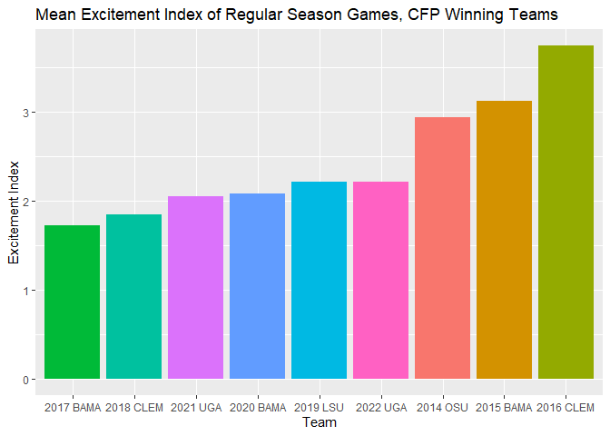

```r
ggplot(data = cfpExcitement, aes(x = team, y = mean)) +
  geom_bar(stat = "identity", aes(x = reorder(team, mean), fill = team)) +
  labs(title = "Mean Excitement Index of Regular Season Games, CFP Winning Teams", x = "Team", y = "Excitement Index") +
  theme(legend.position = "none")
```

The 2017 Crimson Tide were the best at playing joyless murderball, while the 2016 Clemson Tigers played the most exciting games of any of the College Football Playoff winners.

```r
FSU2014 <- games(year = 2014, team = "Florida State", apiKey = cfbd_api_key)
mean(as.numeric(FSU2014$excitement_index))
```

```
## [1] 4.789804
```

For comparison, 2014 Florida State, a team known for being on the right side of numerous close games on their way to a perfect regular season, recorded an average excitement index of 4.789804.

The 2017 FBS season does warrant a closer look. It was a season that featured a lot, from Georgia’s first taste at being among college football’s elite in the playoff era, the last hurrah of Stanford’s time in the spotlight, and the first time the College Football Playoff format was challenged, with 12-0 UCF not being selected for the playoffs and claiming a national championship via the Colley Matrix.

In such a chaotic season, It would be interesting to see which teams were least affected by it. I pulled the records of every FBS team in the 2017 season, and calculated the difference between their actual wins and expected wins.

```r
records2017 <- records(year = 2017, apiKey = cfbd_api_key)
records2017 <- records2017 %>% mutate(win.difference = total.wins - expectedWins)
```

The 5 teams that most overperformed their expected wins in 2017 included the PAC-12 champions USC, Sun Belt co-champions Troy, and your Colley Matrix National Champions UCF.

```r
records2017 %>% select(team, total.wins, expectedWins, win.difference) %>%
  arrange(desc(win.difference), desc(total.wins)) %>% head(5)
```

```
##           team total.wins expectedWins win.difference
## 1          UCF         13         11.1            1.9
## 2        Akron          7          5.3            1.7
## 3         Troy         11          9.3            1.7
## 4          USC         11          9.4            1.6
## 5 Kansas State          8          6.4            1.6
```

The team that most underperformed their expected win total in 2017 was Arkansas State. The top 5 includes a 1-11 Baylor team that was reeling from the fallout of their football scandal.

```r
records2017 %>% select(team, total.wins, expectedWins, win.difference) %>%
  arrange(win.difference, desc(total.wins)) %>% head(5)
```

```
##             team total.wins expectedWins win.difference
## 1 Arkansas State          7          9.4           -2.4
## 2     Miami (OH)          5          7.1           -2.1
## 3          Idaho          4          6.0           -2.0
## 4         Baylor          1          3.0           -2.0
## 5     New Mexico          3          4.7           -1.7
```

Five teams won just as many games as they were expected to in 2017, the most noteworthy being the Wisconsin Badgers. The team finished 12-0, before losing the Big Ten Championship to Ohio State in the time-honored tradition of the Big Ten West team losing to the Big Ten East team in the championship (The Big Ten West team has never won the conference since the current divisions were adopted in 2014) before rebounding with a win over Miami (FL) in the Orange Bowl.

```r
records2017 %>% select(team, total.wins, expectedWins, win.difference) %>%
  arrange(abs(win.difference), desc(total.wins)) %>% head(5)
```

```
##                team total.wins expectedWins win.difference
## 1         Wisconsin         13           13              0
## 2          Michigan          8            8              0
## 3 Northern Illinois          8            8              0
## 4        Cincinnati          4            4              0
## 5    San José State          2            2              0
```

Credit to Wisconsin, however, as their 27-21 loss in the conference championship was a much better showing compared to their previous matchup in 2014:

[video not shown]

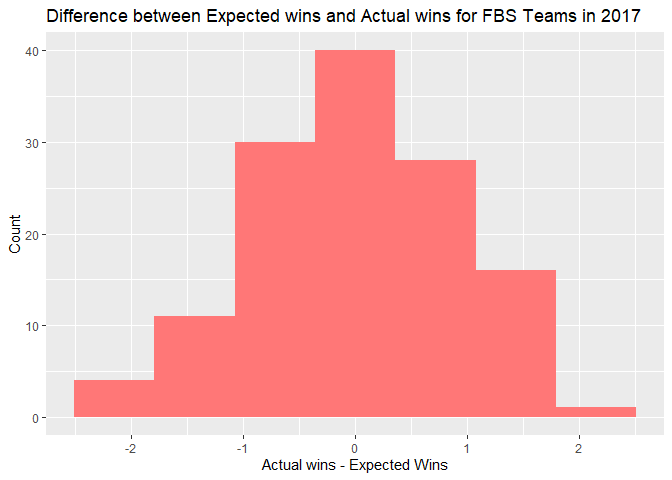

```r
ggplot(data = records2017, aes(x = win.difference)) +
  geom_histogram(bins = 7, fill = "#FF7777") +
  labs(title = "Difference between Expected wins and Actual wins for FBS Teams in 2017",
       x = "Actual wins - Expected Wins", y = "Count")
```

Plotting a histogram of all of the difference values returns a rather bell-shaped distribution. This makes sense, as there is only a limited number of wins to be had, so for a team to overachieve, another team must underachieve.

Going back to the discussion on the national champions, The LSU Tiger’s 2019 team is generally regarded as one of the greatest college football teams of all time. I’ve always maintained that LSU has one of the greatest advantages in college football, being the only power 5 school in the state of Louisiana, a fairly significant recruiting hotbed. Other national championship winning teams such as Alabama, Georgia, and Clemson have to contend with other power 5 schools in their states (Auburn, Georgia Tech, and South Carolina respectively).

To see if my theory holds any water, I compared the number of in-state athletes in LSU’s title winning team to the other CFP winning teams, to see if the ratio of any team is significantly higher.

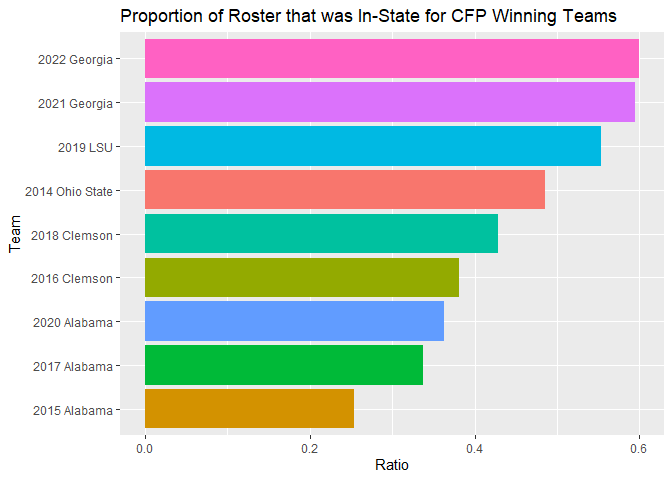

```r
OSU2014Roster <- roster(year = 2014, team = "Ohio State", apiKey = cfbd_api_key)
OSU2014Roster <- OSU2014Roster %>%
  mutate(team = "2014 Ohio State", team_state = "OH") %>%
  select(team, home_state, team_state) %>% replace_na(list(home_state = ""))

BAMA2015Roster <- roster(year = 2015, team = "Alabama", apiKey = cfbd_api_key)
BAMA2015Roster <- BAMA2015Roster %>%
  mutate(team = "2015 Alabama", team_state = "AL") %>%
  select(team, home_state, team_state) %>% replace_na(list(home_state = ""))

CLEM2016Roster <- roster(year = 2016, team = "Clemson", apiKey = cfbd_api_key)
CLEM2016Roster <- CLEM2016Roster %>%
  mutate(team = "2016 Clemson", team_state = "SC") %>%
  select(team, home_state, team_state) %>% replace_na(list(home_state = ""))

BAMA2017Roster <- roster(year = 2017, team = "Alabama", apiKey = cfbd_api_key)
BAMA2017Roster <- BAMA2017Roster %>%
  mutate(team = "2017 Alabama", team_state = "AL") %>%
  select(team, home_state, team_state) %>% replace_na(list(home_state = ""))

CLEM2018Roster <- roster(year = 2018, team = "Clemson", apiKey = cfbd_api_key)
CLEM2018Roster <- CLEM2018Roster %>%
  mutate(team = "2018 Clemson", team_state = "SC") %>%
  select(team, home_state, team_state) %>% replace_na(list(home_state = ""))

LSU2019Roster <- roster(year = 2019, team = "LSU", apiKey = cfbd_api_key)
LSU2019Roster <- LSU2019Roster %>%
  mutate(team = "2019 LSU", team_state = "LA") %>%
  select(team, home_state, team_state) %>% replace_na(list(home_state = ""))

BAMA2020Roster <- roster(year = 2020, team = "Alabama", apiKey = cfbd_api_key)
BAMA2020Roster <- BAMA2020Roster %>%
  mutate(team = "2020 Alabama", team_state = "AL") %>%
  select(team, home_state, team_state) %>% replace_na(list(home_state = ""))

UGA2021Roster <- roster(year = 2021, team = "Georgia", apiKey = cfbd_api_key)
UGA2021Roster <- UGA2021Roster %>%
  mutate(team = "2021 Georgia", team_state = "GA") %>%
  select(team, home_state, team_state) %>% replace_na(list(home_state = ""))

UGA2022Roster <- roster(year = 2022, team = "Georgia", apiKey = cfbd_api_key)
UGA2022Roster <- UGA2022Roster %>%
  mutate(team = "2022 Georgia", team_state = "GA") %>%
  select(team, home_state, team_state) %>% replace_na(list(home_state = ""))

cfpRosters <- rbind(OSU2014Roster, BAMA2015Roster, CLEM2016Roster, BAMA2017Roster,
                    CLEM2018Roster, LSU2019Roster, BAMA2020Roster, UGA2021Roster, UGA2022Roster)

cfpRosters <- cfpRosters %>% group_by(team) %>% mutate(team_state = (team_state == home_state)) %>%
  summarise(ratio = sum(team_state) / n())

ggplot(data = cfpRosters, aes(x = team, y = ratio)) +
  geom_bar(stat = "identity", aes(x = reorder(team, ratio), fill = team)) +
  coord_flip() +
  labs(title = "Proportion of Roster that was In-State for CFP Winning Teams", x = "Team", y = "Ratio") +
  theme(legend.position = "none")
```

I suppose my theory is somewhat reinforced by Ohio State and LSU having higher ratios of in-state athletes than Alabama and Clemson, however I was a bit surprised at Georgia’s national championship winning teams having at or around 60% of their athletes come from in-state.

I may have been a bit generous when I referred to Georgia Tech as a Power 5 school.

Talent is important to the success of a football team. However, just because a team has talent, doesn’t mean they will find success. The 2021 season was noteworthy for many teams starting the season ranked and finishing the season rather poorly. To see which teams overachieved and underachieved considering their rosters in 2021, I tried to plot the winning percentage of each team given their 247Sports talent composite.

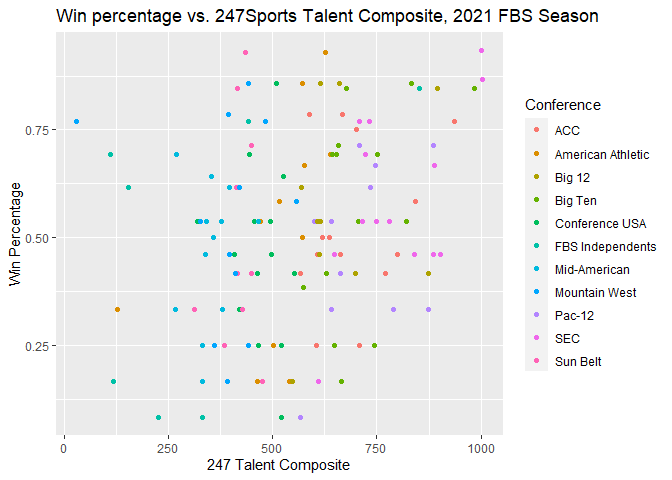

```r
winPercentage2021 <- records(year = 2021, apiKey = cfbd_api_key)
winPercentage2021 <- winPercentage2021 %>%
  select(team, conference, total.games, total.wins) %>% mutate(win.percentage = total.wins / total.games)
talent2021  <- talent(year = 2021, apiKey = cfbd_api_key)
talent2021$talent <- as.numeric(talent2021$talent)
winPercentage2021 <- inner_join(winPercentage2021, talent2021, by = join_by(team == school))

ggplot(data = winPercentage2021, aes(x = talent, y = win.percentage)) +
  geom_point(aes(color = conference)) +
  labs(title = "Win percentage vs. 247Sports Talent Composite, 2021 FBS Season",
       x = "247 Talent Composite", y = "Win Percentage", color = "Conference")
```

It should not come as too large a surprise that the two teams that competed in the national championship game were those with the highest talent composites - Georgia(SEC) and Alabama(SEC). The two teams with the lowest talent composite, Air Force(MW) and Army(Ind), heavily overperformed their talent, a testament to the triple option, although the remaining service academy, Navy(AAC), with the 4th lowest talent composite, was not as fortunate. Playoff team Cincinnati(AAC) finished 12-1 with a middle-of-the-road roster, while the team that perhaps performed the worst with high-end talent was USC(PAC), whose 10th best team talent-wise only yielded a 4-8 record.

I’ll now briefly go through some of the more interesting quirks of recent college football history.

```r
bigTenRecords2016 <- records(year = 2016, conference = "B1G", apiKey = cfbd_api_key)
bigTenRecords2016 %>% select(team, conference, division, total.wins, total.losses) %>%
  arrange(desc(total.wins), total.losses)
```

```
##              team conference division total.wins total.losses
## 1      Ohio State    Big Ten     East         11            2
## 2      Penn State    Big Ten     East         11            3
## 3       Wisconsin    Big Ten     West         11            3
## 4        Michigan    Big Ten     East         10            3
## 5       Minnesota    Big Ten     West          9            4
## 6        Nebraska    Big Ten     West          9            4
## 7            Iowa    Big Ten     West          8            5
## 8    Northwestern    Big Ten     West          7            6
## 9         Indiana    Big Ten     East          6            7
## 10       Maryland    Big Ten     East          6            7
## 11 Michigan State    Big Ten     East          3            9
## 12       Illinois    Big Ten     West          3            9
## 13         Purdue    Big Ten     West          3            9
## 14        Rutgers    Big Ten     East          2           10
```

In 2016, Penn State finished the regular season 11-2 as the Big Ten champions. Ohio State finished 11-1, with their only loss coming against Penn State to deny them their Big Ten Championship Game berth. Come playoff selection time, Ohio State was selected over Penn State, which only goes to show that college football is one of the few sports where losses matter more than wins.

```r
big12Records2008 <- records(year = 2008, conference = "B12", apiKey = cfbd_api_key)
big12Records2008 %>% select(team, conference, division, total.wins, total.losses) %>%
  arrange(desc(total.wins), total.losses)
```

```
##              team conference division total.wins total.losses
## 1           Texas     Big 12    South         12            1
## 2        Oklahoma     Big 12    South         12            2
## 3      Texas Tech     Big 12    South         11            2
## 4        Missouri     Big 12    North         10            4
## 5        Nebraska     Big 12    North          9            4
## 6  Oklahoma State     Big 12    South          9            4
## 7          Kansas     Big 12    North          8            5
## 8        Colorado     Big 12    North          5            7
## 9    Kansas State     Big 12    North          5            7
## 10         Baylor     Big 12    South          4            8
## 11      Texas A&M     Big 12    South          4            8
## 12     Iowa State     Big 12    North          2           10
```

In 2008, the Big 12 South was caught up in a three-way tie, with Texas, Oklahoma, and Texas Tech each finishing with an 11-1 record. Texas won over Oklahoma, Texas Tech beat Texas, and Oklahoma beat Texas Tech. Owing to their records, whoever was chosen to represent the Big 12 South in the conference championship game would likely win and play in the BCS National Championship game. The tiebreaker would ultimately be the BCS rankings, and Oklahoma ended up with a National Championship Game berth, meaning that the BCS had effectively influenced its own rankings.

College football is weird.

The last thing I’d like to do is look at the stadiums in which college football games are played.

```r
cfbVenues <- venues(apiKey = cfbd_api_key)
cfbVenues <- cfbVenues %>% select(name, capacity, city, state, location.x, location.y)
cfbVenues %>% select(name, city, state, capacity) %>% arrange(desc(capacity)) %>% head(10)
```

```
##                                      name            city state capacity
## 1                  Bristol Motor Speedway         Briston    TN   162000
## 2                        Michigan Stadium       Ann Arbor    MI   107601
## 3                          Beaver Stadium University Park    PA   106572
## 4                            Ohio Stadium        Columbus    OH   102780
## 5                              Kyle Field College Station    TX   102733
## 6                         Neyland Stadium       Knoxville    TN   102455
## 7                           Tiger Stadium     Baton Rouge    LA   102321
## 8                    Bryant Denny Stadium      Tuscaloosa    AL   101821
## 9  Darrell K Royal-Texas Memorial Stadium          Austin    TX   100119
## 10                           AT&T Stadium       Arlington    TX   100000
```

The largest stadium by capacity to ever host a college football game is Bristol Motor Speedway (featuring a rather egregious typo in the city). In 2016, it hosted Tennessee’s 45-24 win over Virginia Tech, as well as East Tennessee’s 34-31 win over Western Carolina, a testament to the stadium’s ability to host both good racing and good football.

The remaining stadiums in the top ten include three Big Ten stadiums (Michigan, Beaver and Ohio stadiums being Michigan, Penn State and Ohio State’s home stadiums respectively), 4 SEC stadiums (Kyle Field, Neyland, Tiger and Bryant Denny stadiums being Texas A&M, Tennessee, LSU and Alabama’s home stadiums respectively), one Big 12 stadium (Darrell K Royal-Texas Memorial Stadium being the SEC-bound Texas’s home stadium), and another neutral site, with Jerry World (AT&T Stadium) being the sight of the Red River Shootout between Texas and Oklahoma.

I wanted to plot the locations of each stadium to host a college football game in the continental US:

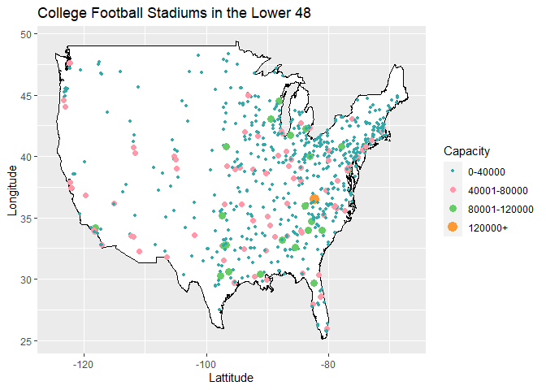

```r
cfbVenues <- cfbVenues %>% filter(!(state %in% c("", "HI", "NSW")))
us <- map_data(map = "usa")
ggplot() +
  geom_map(data = us, map = us, aes(long, lat, map_id = region), color = "black", fill = "white") +
  geom_point(data = cfbVenues, aes(location.y, location.x,
                                   size = cut(capacity, c(-1, 40000, 80000, 120000, Inf)),
                                   color = cut(capacity, c(-1, 40000, 80000, 120000, Inf)))) +
  labs(title = "College Football Stadiums in the Lower 48",
       x = "Lattitude", y = "Longitude", color = "Capacity", size = "Capacity") +
  scale_color_manual(labels = c("0-40000", "40001-80000", "80001-120000", "120000+"),
                    values = c("#33AAAA", "#FF99AA", "#66CC66", "#FF9933")) +
  scale_size_manual(labels = c("0-40000", "40001-80000", "80001-120000", "120000+"),
                    values = c(1, 2, 3, 4))
```